# Social Network Analysis: Lab Exercise 1

## Full name: *Andreas Kontogiannis*

### Student NTUA Username: el15187

#### ECE, NTUA, 2019-2020

## 1<sup>η</sup> Εργαστηριακή Άσκηση: Ανάλυση & Μελέτη Σύνθετων Τοπολογιών Δικτύου

In this lab exercise, we will study the below topologies:  
-Random Exploration Graph (REG),  
-Erdos-Renyi (RGER),  
-Gilbert,  
-Random Geometric Graphs (RGG),  
-Barabasi-Albert (SF),  
-Watts-Strogatz (SW)  
Network Analysis methods and metrics, including node degree, node strength, centrality, shortest-paths, clustering coefficient, graph connectivity and threshold behavior, will be applied on the above topologies.

Πίνακας $1$: Σύνθετα δίκτυα και χαρακτηριστικές παράμετροι

| Network Type | Model | Identifier | Parameters |
| --- | --- | --- | --- |
| Lattice | Finite | REG | Nodes $n$ |
|  |  |  | Bαθμός $d$ |
| Random graph | Erdos-Renyi | RG(ER) | Nodes $N$ |
|  |  |  | Links $M$ |
| Random graph | Gilbert | RG(G) | Nodes $n$ |
|  |  |  | Link probability $p$ |
| Random Geometric Graph | Flat | RGG | Area $L\times L$ |
|  |  |  | Radius $R$ |
|  |  |  | Nodes $n$ |
| Scale-free | Barabasi-Albert | SF(BA) | Nodes $n$ |
|  |  |  | Initial Lattice Degree $d$ |
| Small-world | Watts-Strogatz | SW(WS) | Nodes $n$ |
|  |  |  | Initial Lattice Degree $d$ |
|  |  |  | Link probability $g_p$ |

```python
# AM = el15187
n = 170
```

```python
!pip install networkx
!pip install matplotlib
!pip install pandas
!pip install numpy
!pip install seaborn
```

```python
%matplotlib inline
import matplotlib
import networkx as nx
import matplotlib.pyplot as plt
import numpy as np
import pandas as pd
import seaborn as sns
```

### Α) Δημιουργία και οπτικοποίηση σύνθετων τύπων δικτύου

Κατασκευή και οπτικοποίηση της τοπολογίας REG για βαθμό πλέγματος $d = 4$

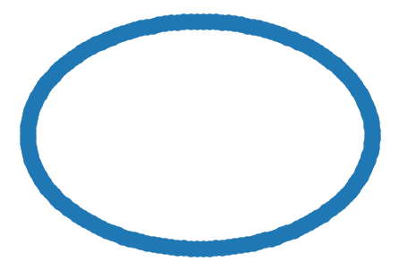

```python
d = 4

# Lattice -> p = 0
REG =  nx.watts_strogatz_graph(n, d, 0, seed=None)

# Visualization
nx.draw_circular(REG)
```

Κατασκευή και οπτικοποίηση της τοπολογίας RG(ER) για αριθμό συνδέσεων $M = 750$

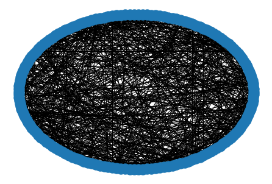

```python
M = 750

# για την κατασκευή του RGER χρησιμοποιήστε την gnm_random_graph από το networkx
RGER = nx.gnm_random_graph(n, M)

# Visualization of RGER
nx.draw_circular(RGER)
```

Κατασκευή και οπτικοποίηση της τοπολογίας RGG σε περιοχή $L\times L = 1$ (unit cube) και ακτίνα σύνδεσης $R=0.25$

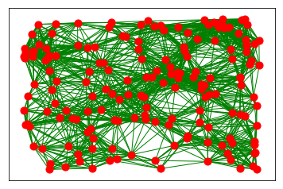

```python
R = 0.25
L = 1
n = 170

# για την κατασκευή του RGG, χρησιμοποιήστε την random_geometric_graph από το networkx
RGG = nx.random_geometric_graph(n, R, dim=2)
# για την οπτικοποίηση, χρησιμοποιήστε draw_networkx_edges, draw_networkx_nodes.
# Για τη θέση των κόμβων στην τετράγωνη περιοχή, χρησιμοποιήστε την get_node_attributes από το networkx.
pos = nx.get_node_attributes(RGG, 'pos')
nx.draw_networkx_nodes(RGG, pos, node_size=82.5, node_color="r")
nx.draw_networkx_edges(RGG, pos, edge_width=0.06, edge_color="g")
```

Κατασκευή και οπτικοποίηση της τοπολογίας SF για βαθμό αρχικού πλέγματος $d=4$

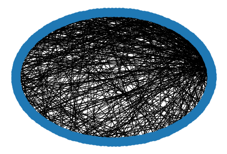

```python
d = 4

# για την κατασκευή του SF, χρησιμοποιήστε την barabasi_albert_graph από το networkx.
SF = nx.barabasi_albert_graph(n, d)

# για την οπτικοποίηση, χρησιμοποιήστε την draw_circular από το networkx.
nx.draw_circular(SF)
```

Κατασκευή και οπτικοποίηση της τοπολογίας SW για βαθμό αρχικού πλέγματος $d=4$ και πιθανότητας ανασύνδεσης $p=0.3$

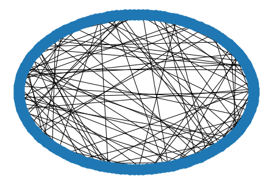

```python
n = 170
d = 4
p = 0.3

# για την κατασκευή του SW, χρησιμοποιήστε την watts_strogatz_graph από το networkx.
SW = nx.watts_strogatz_graph(n, d, p)

# για την οπτικοποίηση, χρησιμοποιήστε την draw_circular από το networkx.
nx.draw_circular(SW)
```

### B) Μελέτη βαθμού κόμβων

Για κάθε μια από τις τοπολογίες REG, RG(ER), RGG, SF(BA) και SW(WS)

##### 1) Να υπολογιστεί ο βαθμός κάθε κόμβου

The **degree** of a node is the number of edges connected to the node.

```python
# χρησιμοποιήστε την degree του networkx

def find_degree(G):
    return dict(G.degree())

# REG degree
reg_degree = find_degree(REG)
print("REG Degree")
print(reg_degree)
print()

# RGER degree
rger_degree = find_degree(RGER)
print("RGER Degree")
print(rger_degree)
print()

# RGG degree
rgg_degree = find_degree(RGG)
print("RGG Degree")
print(rgg_degree)
print()

# SF degree
sf_degree = find_degree(SF)
print("SF Degree")
print(sf_degree)
print()

# SW degree
sw_degree = find_degree(SW)
print("SW Degree")
print(sw_degree)
```

```
REG Degree
{0: 4, 1: 4, 2: 4, 3: 4, 4: 4, 5: 4, 6: 4, 7: 4, 8: 4, 9: 4, 10: 4, 11: 4, 12: 4, 13: 4, 14: 4, 15: 4, 16: 4, 17: 4, 18: 4, 19: 4, 20: 4, 21: 4, 22: 4, 23: 4, 24: 4, 25: 4, 26: 4, 27: 4, 28: 4, 29: 4, 30: 4, 31: 4, 32: 4, 33: 4, 34: 4, 35: 4, 36: 4, 37: 4, 38: 4, 39: 4, 40: 4, 41: 4, 42: 4, 43: 4, 4…

RGER Degree
{0: 7, 1: 11, 2: 10, 3: 12, 4: 9, 5: 11, 6: 8, 7: 2, 8: 8, 9: 12, 10: 8, 11: 7, 12: 10, 13: 8, 14: 5, 15: 9, 16: 6, 17: 10, 18: 6, 19: 11, 20: 10, 21: 8, 22: 13, 23: 5, 24: 8, 25: 8, 26: 8, 27: 9, 28: 9, 29: 11, 30: 8, 31: 6, 32: 8, 33: 7, 34: 3, 35: 10, 36: 8, 37: 8, 38: 5, 39: 11, 40: 8, 41: 8, 42…

RGG Degree
{0: 24, 1: 19, 2: 20, 3: 22, 4: 31, 5: 15, 6: 39, 7: 19, 8: 27, 9: 34, 10: 28, 11: 28, 12: 26, 13: 15, 14: 22, 15: 26, 16: 34, 17: 27, 18: 19, 19: 29, 20: 22, 21: 33, 22: 28, 23: 28, 24: 25, 25: 27, 26: 29, 27: 24, 28: 31, 29: 22, 30: 20, 31: 33, 32: 20, 33: 25, 34: 27, 35: 34, 36: 25, 37: 24, 38: 3…

SF Degree
{0: 17, 1: 2, 2: 6, 3: 29, 4: 35, 5: 41, 6: 30, 7: 13, 8: 30, 9: 31, 10: 32, 11: 12, 12: 14, 13: 19, 14: 22, 15: 16, 16: 9, 17: 16, 18: 14, 19: 7, 20: 17, 21: 15, 22: 7, 23: 16, 24: 9, 25: 11, 26: 8, 27: 16, 28: 6, 29: 17, 30: 10, 31: 9, 32: 15, 33: 11, 34: 7, 35: 17, 36: 6, 37: 13, 38: 7, 39: 6, 40…

SW Degree
{0: 4, 1: 7, 2: 5, 3: 3, 4: 4, 5: 3, 6: 4, 7: 4, 8: 4, 9: 4, 10: 3, 11: 6, 12: 4, 13: 3, 14: 4, 15: 5, 16: 3, 17: 3, 18: 2, 19: 3, 20: 4, 21: 3, 22: 4, 23: 6, 24: 4, 25: 5, 26: 5, 27: 4, 28: 4, 29: 3, 30: 4, 31: 4, 32: 4, 33: 3, 34: 3, 35: 4, 36: 4, 37: 4, 38: 5, 39: 3, 40: 3, 41: 7, 42: 4, 43: 5, 4…
```

##### 2) Να αναπαρασταθεί (plot) η κατανομή βαθμών κόμβων του δικτύου (δηλαδή, για κάθε βαθμό πόσοι κόμβοι έχουν αυτό το βαθμό) καθώς και η συγκεντρωτική κατανομή βαθμού κόμβου (δηλαδή για κάθε βαθμό πόσοι κόμβοι έχουν το πολύ αυτό το βαθμο)

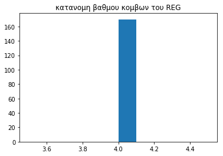

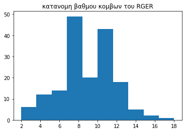

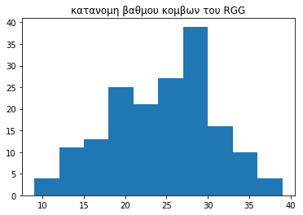

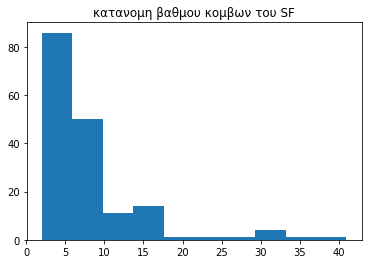

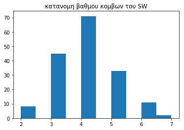

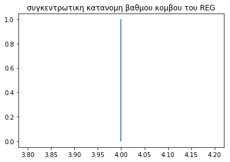

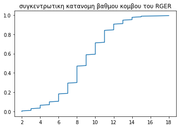

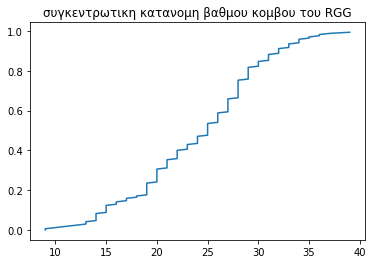

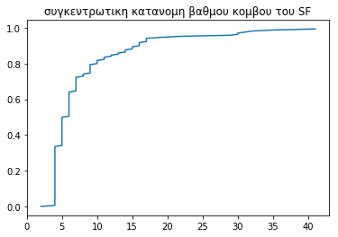

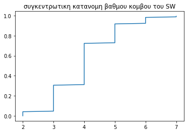

```python
#για την κατανομή βαθμού κόμβου, χρησιμοποιήστε την hist του matplotlib

# graph_degree: dict{pos} = degree
def list_node_degrees(graph_degree):
    return list(graph_degree.values())

def find_discriminant_degrees(graph_degree):
    degrees = list_node_degrees(graph_degree)
    max_degree = np.max(degrees)
    # Frequency Table of degrees
    freq_degree = []
    for i in range(max_degree + 1):
        freq_degree.append(0)

    for degree in degrees:
        freq_degree[degree] += 1

    x_hist = []
    for i in range(len(freq_degree)):
        if (freq_degree[i] > 0):
            for j in range(freq_degree[i]):
                x_hist.append(i)
    return x_hist

plt.figure(1)
plt.title("κατανομη βαθμου κομβων του REG")
plt.hist(find_discriminant_degrees(reg_degree))
plt.figure(2)
plt.title("κατανομη βαθμου κομβων του RGER")
plt.hist(find_discriminant_degrees(rger_degree))
plt.figure(3)
plt.title("κατανομη βαθμου κομβων του RGG")
plt.hist(find_discriminant_degrees(rgg_degree))
plt.figure(4)
plt.title("κατανομη βαθμου κομβων του SF")
plt.hist(find_discriminant_degrees(sf_degree))
plt.figure(5)
plt.title("κατανομη βαθμου κομβων του SW")
plt.hist(find_discriminant_degrees(sw_degree))

#για τη συγκεντρωτική κατανομή του διανύσματος values (σε αυτή την περίπτωση τa degree values),
#χρησιμοποιήστε την plot(X,Y) του matplotlib
Xreg = np.sort(list(reg_degree.values()))
Xrger = np.sort(list(rger_degree.values()))
Xrgg = np.sort(list(rgg_degree.values()))
Xsf = np.sort(list(sf_degree.values()))
Xsw = np.sort(list(sw_degree.values()))
Y = np.array(range(n))/float(n)
plt.figure(6)
plt.title("συγκεντρωτικη κατανομη βαθμου κομβου του REG")
plt.plot(Xreg, Y)
plt.figure(7)
plt.title("συγκεντρωτικη κατανομη βαθμου κομβου του RGER")
plt.plot(Xrger, Y)
plt.figure(8)
plt.title("συγκεντρωτικη κατανομη βαθμου κομβου του RGG")
plt.plot(Xrgg, Y)
plt.figure(9)
plt.title("συγκεντρωτικη κατανομη βαθμου κομβου του SF")
plt.plot(Xsf, Y)
plt.figure(10)
plt.title("συγκεντρωτικη κατανομη βαθμου κομβου του SW")
plt.plot(Xsw, Y)
```

##### 3) Να υπολογιστεί ο μέσος βαθμός κόμβου καθώς και η διασπορά των βαθμών κόμβου για κάθε μια από τις εν λόγω τοπολογίες

```python
#χρησιμοποιήστε τις mean, var του numpy
print("Mean REG: " + str(np.mean(list(reg_degree.values()))))
print("Var REG: " + str(np.var(list(reg_degree.values()))))
print()

print("Mean RGER: " + str(np.mean(list(rger_degree.values()))))
print("Var RGER: " + str(np.var(list(rger_degree.values()))))
print()

print("Mean RGG: " + str(np.mean(list(rgg_degree.values()))))
print("Var RGG: " + str(np.var(list(rgg_degree.values()))))
print()

print("Mean SF: " + str(np.mean(list(sf_degree.values()))))
print("Var SF: " + str(np.var(list(sf_degree.values()))))
print()

print("Mean SW: " + str(np.mean(list(sw_degree.values()))))
print("Var SW: " + str(np.var(list(sw_degree.values()))))
```

```
Mean REG: 4.0
Var REG: 0.0

Mean RGER: 8.823529411764707
Var RGER: 7.721799307958476

Mean RGG: 24.03529411764706
Var RGG: 39.43404844290658

Mean SF: 7.811764705882353
Var SF: 40.717508650519044

Mean SW: 4.0
Var SW: 1.011764705882353
```

**Σχολιασμός αποτελεσμάτων**  
Ξεκινώντας απο το REG, εφόσον είναι πεπερασμένο, δεν έχει ουδεμία τυχαιότητα, αφού ο βαθμός όλων των κόμβων πρέπει οπωσδήποτε να είναι ο ίδιος, δηλαδή ίσον με 4. Με τον ίδιο τρόπο, περιμένουμε η μέση τιμή των βαθμών των κόμβων να είναι και αυτή ίση με 4 και η διασπορά προφανώς ίση με το 0. Έτσι, η κατανομή του βαθμού των κόμβων αποτελεί την Dirac function.

Για το Erdos-Renyi (RGER) μοντέλο, o γράφος διαλέγεται uniformly τυχαία από το σύνολο όλων των γράφων που έχουν Ν κόμβους και Μ ακμές. Έτσι, η πιθανότητα ένας κόμβος να έχει Κ βαθμό ακολουθεί την Poisson distribution. H μέση τιμή των βαθμών κόμβων περιμένουμε να είναι περίπου ίση με το $p\cdot(Ν-1)$, όπου p η πιθανότητα ένας γράφος να διαλεχτεί από το πλήθος των γράφων που ορίζει το μοντέλο. Αύτο έχει ως αποτέλεσμα, να περιμένουμε την διασπορά να έχει την ίδια τιμή με την μέση τιμή, κάτι το οποίο εν μέρει ισχύει και στο πείραμά μας, αφού οι δύο τιμές έχουν πολύ μικρή απόκλιση.

Στο Barabasi-Albert (SF) μοντέλο, το δίκτυο αρχικοποιείται απο έναν αρχικό συνδεδεμένο γράφο που εχει $Μ_0$ κόμβους. Στην συνέχεία, νέοι κόμβοι προσθέτονται, ένας κάθε φορά. Κάθε νέος κόμβος συνδέεται με $ Μ \leq Μ_0$ υπάρχοντες κόμβους με πιθανότητα ανάλογη του αριθμού των συνδέσεων που οι υπάρχοντες κόμβοι ήδη έχουν.
Πιο αναλυτικά:
$$p_i = \frac {k_i} {\sum_{j} k_j}$$
Έτσι, οι νέοι κόμβοι έχουν την προτίμηση να συνδέονται με τους πιο heavily υπάρχοντες linked κόμβους. Όπως, παρατηρούμε και στο πείραμά μας, η κατανομή των κόμβων ακολούθει power-law distribution. Αυτό εξηγεί και την μεγάλη διασπορά που έχουμε, που αν και πεπερασμένη, αποκλίνει πολύ σε σχέση με την μέση τιμή του βαθμού κόμβου. Με αυτόν τον τρόπο, καταφέρνουμε να συνυπάρχουμε λίγους κόμβους μεγάλου βαθμού με πολλούς κόμβους μικρού βαθμού.

Τέλος, στο Watts-Strogatz (SW) μοντέλο, δοθέντους του Ν, αριθμού κόμβων, του μέσου βαθμού κόμβου Κ και της ειδικής παραμέτρου β, κατασκευάζεται ένας μη κατευθυνόμενος γράφος με Ν κόμβους και $\frac{NK}{2}$ ακμές. Γνωρίζουμε ότι η μέση τιμή βαθμού κόμβου πρέπει να παίρνει την τιμή του Κ που δώσαμε, κάτι που ικανοποιείται επιτυχώς και στο πείραμά μας. Επιπλέον, η κατανομή του βαθμού κόμβου φαίνεται να ακολουθεί την heavy-tail distribution, που σημαίνει στο πείραμά μας ότι οι περισσότεροι κόμβοι τείνουν να έχουν βαθμό μεγάλης τιμής, δηλαδή κοντά στην μέση τιμή Κ, εν προκειμένου ίση με 4, και οι εναπομείναντες να συμπληρώνονται μεταξύ τους με τιμές κάτω ή πάνω απο το Κ.

### Γ) Δίκτυα με βάρη

Για ένα δίκτυο με βάρη στις συνδέσεις του, όμοια με τον πίνακα γειτνίασης, ορίζεται ο πίνακας βαρών, $W=[w_{ij}]$, όπου με $w_{ij}>0$ συμβολίζεται το βάρος στην ακμή που ενώνει τους κόμβους $i,j$. Για μη-κατευθυνόμενους γράφους ο πίνακας $W$ είναι συμμετρικός.

Για κάθε μια από τις τοπολογίες REG, RG(ER), RGG, SF(BA) και SW(WS) του πίνακα, να δημιουργηθεί τυχαίος πίνακας βαρών. Το εύρος των βαρών να κυμαίνεται στο διάστημα $[1,10]$.

```python
# για τιμές στο [1,10]: α=1, b=10, weight=np.random.rand()*(b-a) + a
# για την προσθήκη βαρών στις ακμές, χρησιμοποήστε την add.edge του networkx
a = 1
b = 10

def array_line(n):
    return [np.random.rand()*(b-a) + a for i in range(n)]

def adjacent_array(n):
    # Adjacent Weighted Array
    weight_array = np.array([array_line(n) for i in range(n)])
    # Symmetric Array
    symmetric = (np.maximum(weight_array, weight_array.transpose()))
    # (i,i) = 0
    for i in range(n):
        symmetric[i][i] = 0

    return symmetric

# Adding weighted edge
def addWeightedEdge(G, n):
    adj = adjacent_array(n)
    for e in G.edges():
        n0 = e[0]
        n1 = e[1]
        G[n0][n1]['weight'] = adj[n0][n1]
    return G

reg_weighted = addWeightedEdge(REG, n)

rger_weighted = addWeightedEdge(RGER, n)

rgg_weighted = addWeightedEdge(RGG, n)

sf_weighted = addWeightedEdge(SF, n)

sw_weighted = addWeightedEdge(SW, n)
```

##### i) Να υπολογιστεί η δύναμη του κάθε κόμβου

**Node Strength**: The sum of weights attached to ties belonging to a node

```python
#δίνεται η συνάρτηση strength που έχει ως όρισμα την τοπολογία που παράξατε στο ερώτημα Α:
def strength(G):
    weights_list = []
    for i in range(len(G.adj)):
        a = []
        for j in range(len(G.adj[i].items())):
            d = list(G.adj[i].values())[j]['weight']
            a.append(d)
        weights_list.append(a)
    node_weights = []
    for node in weights_list:
        node_weights.append(sum(node))
    return node_weights

REG_strength = strength(reg_weighted)
RGER_strength = strength(rger_weighted)
RGG_strength = strength(rgg_weighted)
SF_strength = strength(sf_weighted)
SW_strength = strength(sw_weighted)
print("REG Strength")
print(REG_strength)
print()

print("RGER Strength")
print(RGER_strength)
print()

print("RGG Strength")
print(RGG_strength)
print()

print("SF Strength")
print(SF_strength)
print()

print("SW Strength")
print(SW_strength)
print()
```

```
REG Strength
[25.13123219538364, 24.40589192208907, 29.253759346020402, 25.09468574658562, 32.02934257838217, 25.742724969987037, 26.693722245348876, 26.232741986451806, 34.88561532359452, 31.39306045186381, 33.48364796344666, 32.497167500738946, 30.272698636232654, 33.96905098920826, 29.498090471282197, 28.9106…

RGER Strength
[56.8367761892746, 70.78209201957968, 77.80026475751717, 73.46291757625697, 72.2492117235408, 79.28674906425641, 60.696741616694815, 10.149790319660287, 62.208356662978474, 86.40484073028607, 53.74777837234552, 63.92673481618927, 74.69521791439074, 60.283014292405554, 31.965552645965133, 69.43866953…

RGG Strength
[181.71628177261144, 132.77493973774037, 132.74340151944236, 158.82779086300224, 242.15235600839003, 111.53355286973714, 256.3462002119157, 124.81666049516043, 184.80035471127877, 239.16382116871944, 203.91259893215414, 207.3460897789175, 169.27350294098196, 96.81616776145806, 158.76615719875656, 18…

SF Strength
[115.8950306586993, 10.431357943501785, 38.60467931029757, 227.3598206730538, 243.46333901975245, 297.89030600499945, 212.336104719174, 88.16747712192004, 186.32752182968744, 226.07542378044266, 223.4715029663303, 86.54539244868157, 101.60543727375061, 143.00204181875057, 150.46208681131978, 119.146…

SW Strength
[32.29115613379055, 57.83185644709222, 35.594878674098375, 22.14417606890768, 25.936565302369345, 19.241995223151818, 24.33937656842413, 23.53946215634206, 19.576312887705832, 27.383957449467978, 17.55833027917305, 49.301129292725186, 24.59161005972858, 21.184864102453986, 19.520166982883673, 33.958…
```

##### ii) Να αναπαρασταθεί η συγκεντρωτική κατανομή δύναμης (cumulative strength distribution) των κόμβων του δικτύου (σε κάθε τιμή δύναμης αντιστοιχίζεται το πλήθος των κόμβων με δύναμη μικρότερη ή ίση από αυτή)

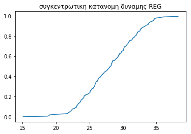

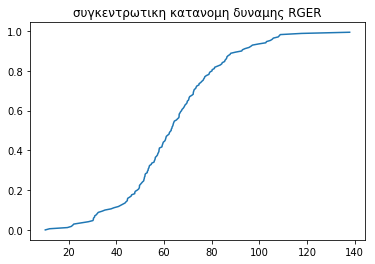

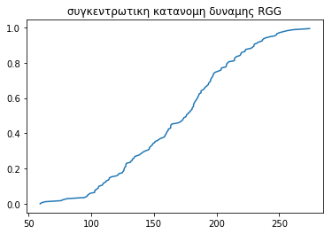

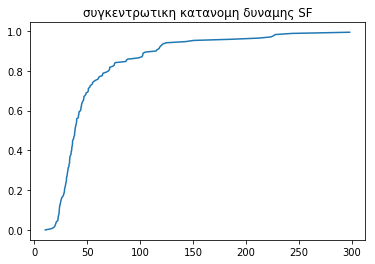

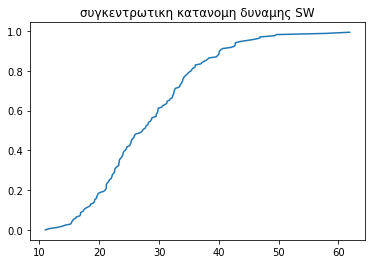

```python
# Οπως Β (ii)
Xreg = np.sort(list(REG_strength))
Xrger = np.sort(list(RGER_strength))
Xrgg = np.sort(list(RGG_strength))
Xsf = np.sort(list(SF_strength))
Xsw = np.sort(list(SW_strength))
Y = np.array(range(n))/float(n)
plt.figure(6)
plt.title("συγκεντρωτικη κατανομη δυναμης REG")
plt.plot(Xreg, Y)

plt.figure(7)
plt.title("συγκεντρωτικη κατανομη δυναμης RGER")
plt.plot(Xrger, Y)

plt.figure(8)
plt.title("συγκεντρωτικη κατανομη δυναμης RGG")
plt.plot(Xrgg, Y)

plt.figure(9)
plt.title("συγκεντρωτικη κατανομη δυναμης SF")
plt.plot(Xsf, Y)

plt.figure(10)
plt.title("συγκεντρωτικη κατανομη δυναμης SW")
plt.plot(Xsw, Y)
```

##### iii) Να υπολογιστεί η μέση δύναμη (και η διασπορά extra) για όλους τους κόμβους

```python
print("Strength evaluation")
print()

print("Mean Strength REG: " + str(np.mean(list(REG_strength))))
print("Var Strength REG: " + str(np.var(list(REG_strength))))
print()

print("Mean Strength RGER: " + str(np.mean(list(RGER_strength))))
print("Var Strength RGER: " + str(np.var(list(RGER_strength))))
print()

print("Mean Strength RGG: " + str(np.mean(list(RGG_strength))))
print("Var Strength RGG: " + str(np.var(list(RGG_strength))))
print()

print("Mean Strength SF: " + str(np.mean(list(SF_strength))))
print("Var Strength SF: " + str(np.var(list(SF_strength))))
print()

print("Mean Strength SW: " + str(np.mean(list(SW_strength))))
print("Var Strength SW: " + str(np.var(list(SW_strength))))
```

```
Strength evaluation

Mean Strength REG: 27.980709068644096
Var Strength REG: 16.197141115416013

Mean Strength RGER: 63.56800272488933
Var Strength RGER: 452.8300031732606

Mean Strength RGG: 169.11896422399693
Var Strength RGG: 2105.871175283833

Mean Strength SF: 54.50090911793401
Var Strength SF: 2103.2814145928237

Mean Strength SW: 28.207007962122354
Var Strength SW: 81.6349414859726
```

**Σχολιασμός Αποτελεσμάτων**

Για το RGER μοντέλο, περιμένουμε η συγκεντρωτική κατανομή της δύναμης να αυξάνεται σε ορισμένα σημεία απότομα, αφού ο βαθμός κόμβου ακολουθεί την Poisson distribution. Αυτό βέβαια πάλι κυμαίνεται και από τις τιμές των βαρών για τους κόμβους με μεγάλο βαθμό. Στο πείραμά μας, ωστόσο, μπορούμε να διακρίνουμε δυο τέτοιες περιοχές, όπου αυξάνεται αρκετά η συνολική δύναμη. Όσον αφορά την μέση τιμή της δύναμης, περιμένουμε κάποιοι κόμβοι να έχουν μεγάλη δύναμη και κάποιοι ελάχιστη, με αποτέλεσμα να μην έχουμε ούτε πολύ μεγάλη ούτε πολύ μικρή μέση τιμή.

Για το RGG μοντέλο, αναλόγως την τιμή που έχουμε δώσει στο r, περιμένουμε ο κάθε κόμβος να συνδέεται με λίγους ή πολλούς άλλους κόμβους. Στο πείραμά μας, προφανώς, η τιμή του r επιτρέπει μεγάλο μέσο βαθμό κόμβου και άρα μεγάλη μέση δύναμη.

Για το SF μοντέλο, επείδη υπάρχουν λίγοι κόμβοι με μεγάλο βαθμό κόμβου και πολλοί με μικρό, αυτό συνεπάγεται ότι θα υπάρχουν λίγοι κόμβοι με πολύ μεγάλη δύναμη και πολλοί με μικρή. Έτσι, περιμένουμε τεράστια διασπορά στην δύναμη του γράφου και σχετικά μεγάμη μέση δύναμη.

Τέλος για το SW μοντέλο, περιμένουμε παρόμοια μέση τιμή δύναμης με το REG μοντέλο, αφού έχουν το ίδιο mean degree, $Κ=4$, ενώ περιμένουμε σημαντική διασπορά δύναμης διότι το SW degree ακολουθεί την heavy-tailed distribution και άρα αρκετοί κόμβοι θα έχουν δύναμη που θα αποκλίνει από την μέση τιμή.

### Δ) Υπολογισμός μέσου μήκους μονοπατιού

Για κάθε μια από τις τοπολογίες REG, RG(ER), RGG, SF(BA) και SW(WS) του πίνακα, να υπολογιστεί το μέσο μήκος μονοπατιού και η διασπορά του στο δίκτυο. Να παρουσιαστούν συγκεντρωτικά τα αποτελέσματα. Πραγματοποιήστε συγκρίσεις και εξηγήστε με βάση τα χαρακτηριστικά της κάθε τοπολογίας όπως εξηγήθηκαν στη θεωρία.

```python
# χρησιμοποήστε την all_pairs_shortest_path_length του networkx
def compute_path_lengths(G):
    return nx.all_pairs_shortest_path_length(G)

REG_path_lengths = list(compute_path_lengths(REG))
RGER_path_lengths = list(compute_path_lengths(RGER))
RGG_path_lengths = list(compute_path_lengths(RGG))
SF_path_lengths = list(compute_path_lengths(SF))
SW_path_lengths = list(compute_path_lengths(SW))

def getLengths(G_path_lengths):
    lengths = []
    for item in G_path_lengths:
        item_dict = item[1]
        for value in item_dict.values():
            lengths.append(value)

    return lengths

REG_lengths = getLengths(REG_path_lengths)
RGER_lengths = getLengths(RGER_path_lengths)
RGG_lengths = getLengths(RGG_path_lengths)
SF_lengths = getLengths(SF_path_lengths)
SW_lengths = getLengths(SW_path_lengths)

print("Mean path length REG: " + str(np.mean(REG_lengths)))
print("Variance of path length REG: " + str(np.var(REG_lengths)))
print()

print("Mean path length RGER: " + str(np.mean(RGER_lengths)))
print("Variance of path length RGER: " + str(np.var(RGER_lengths)))
print()

print("Mean path length RGG: " + str(np.mean(RGG_lengths)))
print("Variance of path length RGG: " + str(np.var(RGG_lengths)))
print()

print("Mean path length SF: " + str(np.mean(SF_lengths)))
print("Variance of path length SF: " + str(np.var(SF_lengths)))
print()

print("Mean path length SW: " + str(np.mean(SW_lengths)))
print("Variance of path length SW: " + str(np.var(SW_lengths)))
```

```
Mean path length REG: 21.5
Variance of path length REG: 150.6264705882353

Mean path length RGER: 2.582076124567474
Variance of path length RGER: 0.4735749284611057

Mean path length RGG: 2.898339100346021
Variance of path length RGG: 1.5821218088863878

Mean path length SF: 2.564290657439446
Variance of path length SF: 0.4440674034075263

Mean path length SW: 4.3439446366782
Variance of path length SW: 1.754781671675387
```

**Σχολιασμός Αποτελεσμάτων**

Για το REG model, περιμένουμε σταθέρο μέσο μήκος μονοπατιού, αφού όλοι οι κόμβοι έχουν το ίδιο degree. Στο πείραμά μας, ισούται με 21.5. Το μεγάλο μήκος μονοπατιού οφείλεται στο ότι υπάρχουν κορυφές, που συνδέονται με μία ακμή αλλά και άλλες που έχουν μέγιστη απόσταση μεταξύ τους, με αποτέλεσμα να μην μπορεί να δημιουργηθεί μικρό ελάχιστο μονοπάτι μεταξύ τους που δεν θα διασχίζει την πλειονότητα των κόμβων.

Για το RGER model, περιμένουμε σχετικά μικρό μέσο μήκος μονοπατιού. Στην άσκησή μας, παίρνουμε μικρό μήκος μονοπατιού, το οποίο είναι της τάξης του $logN$. Eπείδη έχουμε μεγάλο mean degree, δημιουργείται giant component και έτσι μειώνεται το μέσο μήκος μονοπατιού.

Για το RGG model, περιμένουμε μεγάλο μέσο μήκος μονοπατιού, κάτι το οποίο, ωστόσο, εξαρτάται από την Ευκλίδεια απόσταση μεταξύ των κόμβων στον $R^d$, εδώ $R^2$, και την τιμή της παραμέτρου r που έχουμε ορίσει από προηγουμένως. Για τιμή του r που επιτρέπει σχετικά μεγάλες αποστάσεις να δημιουργούν ακμές, το μέσο μήκος μονοπατιού αναμένεται να είναι σχετικά μικρό, όπου στην περίπτωση μας είναι αρκετά μεγάλη η ακτίνα r και το μέσο μήκος μονοπατιού είναι σχετικά κοντά στο $logN$.

Τέλος για το SW model, λαμβάνουμε μέσο μήκος μονοπατιού κοντά $\frac {lnN}{lnK}=3.7$, που είναι και αναμενόμενο από την θεωρία του SW mode.

### Ε) Υπολογισμός συντελεστή ομαδοποίησης (ΣΟ)

**ΟΡΙΣΜΟΣ**  
The **local clustering coefficient** $C_i$ for a vertex $u_i$ is given by the proportion of links between the vertices within its neighbourhood divided by the number of links that could possibly exist between them.

##### 1) Αναλυτικός υπολογισμός του ΣΟ

Για κάθε μια από τις παρακάτω τοπολογίες να υπολογιστεί αναλυτικά (να φαίνονται οι πράξεις) το τοπικό ΣΟ του κάθε κόμβου και να δειχθεί η κατανομή του τοπικού ΣΟ για όλους τους κόμβους.

Στη συνέχεια να υπολογιστεί και να συγκριθεί ο μέσος ΣΟ κάθε τοπολογίας.

```
Topology 1, clustering coefficient for each node:
{0: 0, 1: 0, 2: 0, 3: 0, 4: 0}
Average clustering coefficient for Topology1: 0.0

Topology 2, clustering coefficient for each node:
{0: 0.3333333333333333, 1: 1.0, 2: 1.0, 3: 1.0, 4: 1.0}
Average clustering coefficient for Topology2: 0.8666666666666666

Topology 3, clustering coefficient for each node:
{0: 0.6666666666666666, 1: 0.6666666666666666, 2: 0.6666666666666666, 3: 0.6666666666666666, 4: 0.6666666666666666}
Average clustering coefficient for Topology3: 0.6666666666666666
```

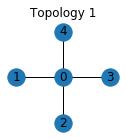

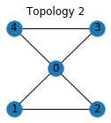

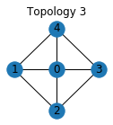

```python
## Προσοχή! Ο παρακάτω κώδικας παράγει τις τοπολογίες στις οποίες θα κάνετε αναλυτικούς υπολογισμούς.
## ΜΗΝ ΤΟΝ ΑΛΛΑΞΕΤΕ

plt.figure(1, figsize=(2,2))
plt.title('Topology 1')
G1 = nx.Graph()
pos = {0: (1, 1), 1: (0, 1), 2: (1, 0), 3: (2, 1), 4: (1, 2)}
G1.add_nodes_from(pos.keys())
G1.add_edges_from([(0,1),(0,2),(0,3),(0,4)])
labels = {}
labels[0] = r'$0$'
labels[1] = r'$1$'
labels[2] = r'$2$'
labels[3] = r'$3$'
labels[4] = r'$4$'
nx.draw_networkx_labels(G1, pos, labels)
nx.draw(G1,pos)
# Dict of clustering coefficient for each node
co1 = nx.clustering(G1)
print("Topology 1, clustering coefficient for each node:")
print(co1)
print("Average clustering coefficient for Topology1: " + str( np.mean(list(co1.values()) )))
print()

plt.figure(2,figsize=(2,2))
plt.title('Topology 2')
G2 = nx.Graph()
pos = {0: (1, 1), 1: (0, 0), 2: (2, 0), 3: (2, 2), 4: (0, 2)}
G2.add_nodes_from(pos.keys())
G2.add_edges_from([(0,1),(0,2),(0,3),(0,4),(1,2),(3,4)])
labels = {}
labels[0] = r'$0$'
labels[1] = r'$1$'
labels[2] = r'$2$'
labels[3] = r'$3$'
labels[4] = r'$4$'
nx.draw_networkx_labels(G2, pos, labels)
nx.draw(G2, pos)
# Dict of clustering coefficient for each node
co2 = nx.clustering(G2)
print("Topology 2, clustering coefficient for each node:")
print(co2)
print("Average clustering coefficient for Topology2: " + str( np.mean(list(co2.values()) )))
print()

plt.figure(3,figsize=(2,2))
plt.title('Topology 3')
G3 = nx.Graph()
pos = {0: (1, 1), 1: (0, 1), 2: (1, 0), 3: (2, 1), 4: (1, 2)}
G3.add_nodes_from(pos.keys())
G3.add_edges_from([(0,1),(0,2),(0,3),(0,4),(1,2),(2,3),(3,4),(4,1)])
labels = {}
labels[0] = r'$0$'
labels[1] = r'$1$'
labels[2] = r'$2$'
labels[3] = r'$3$'
labels[4] = r'$4$'
nx.draw_networkx_labels(G3, pos, labels)
nx.draw(G3,pos)
# Dict of clustering coefficient for each node
co3 = nx.clustering(G3)
print("Topology 3, clustering coefficient for each node:")
print(co3)
print("Average clustering coefficient for Topology3: " + str( np.mean(list(co3.values()) )))
print()
```

#### Αναλυτικός υπολογισμός συντελεστή ομαδοποίησης

O γενικός τύπος που θα εφαρμοστεί και μας δίνει τον τοπικό ΣΟ είναι ο εξής:

$ C_i = 2 \cdot \frac{|e_{jk} \hspace{1mm}: \hspace{1mm} u_j,u_k \in N_i, e_{j,k} \in E|}{k_i(k_i-1)}$

**Topology 1**  
Για κάθε κόμβο του αστεριού παρατηρούμε ότι κανένας από τους neighbors του δεν συνδέεται με κάποιον άλλο neighbor. Οι κόμβοι εκτός τους κέντρου έχουν μοναδικό neighbor τον κεντρικό και ο κεντρικός αν και έχει 4 γείτονες, κανένας τους δεν συνδέεται με κάποιον άλλο. Με αυτόν τον τρόπο, ο αριθμητής του κλάσματος είναι μηδενικός και, άρα, ο τοπικός ΣΟ είναι μηδέν για όλους τους κόμβους. Έτσι, η μέση τιμή του ΣΟ είναι μηδέν.

**Topology 2**  
Στην τοπολογία αυτή έχουμε 2 είδη κόμβων: τον κεντρικό και όλους τους περιφεριακούς του, των οποίων τα χαρακτηριστικά είναι τα ίδια. Έτσι, για κάθε εναν περιφεριακό κόμβο θα ισχύει ότι:  
$C_{περιφεριακού} = \frac{2 \cdot 1}{2 \cdot 1} = 1$  
Για τον κεντρικό κόμβο θα ισχύει ότι έχει 4 γείτονες και αυτοί μεταξύ τους έχουν 2 ακμές άρα:  
$C_{κεντρικού} = \frac{2 \cdot 2}{4 \cdot 3} = \frac{1}{3}$

**Topology 3**  
Κάνοντας χρήση των παραπάνω τύπων έχουμε:  
Για κάθε περιφεριακό κόμβο θα ισχύει ότι:  
$C_{περιφεριακού} = \frac{2 \cdot 2}{3 \cdot 2} = \frac{2}{3} $

Για τον κεντρικό κόμβο θα ισχύει ότι έχει 4 γείτονες και αυτοί μεταξύ τους έχουν 4 ακμές άρα:  
$C_{κεντρικού} = \frac{2 \cdot 4}{4 \cdot 3} = \frac{2}{3}$

Η μέση τιμή για κάθε μια παραπάνω τοπολογία δίνει και τον μέσο τοπικό ΣΟ. Προφανώς, τα παραπάνω αποτελέσματα συμβαδίζουν και με τα αποτελέσματα της βιβλιοθηκής networkx που δείξαμε ανωτέρω.

#### Συγκεντρωτικη Κατανομη ΣΟ κομβων για τις παραπανω τοπολογιες

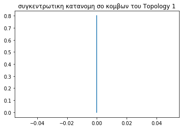

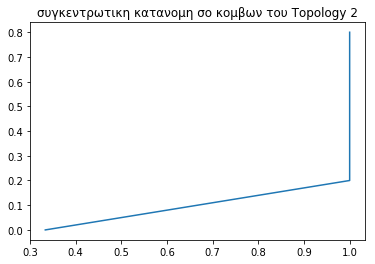

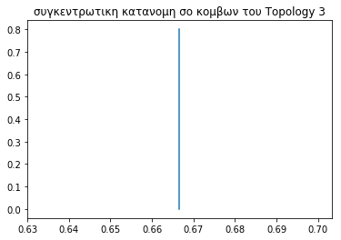

```python
#συγκεντρωτική κατανομή του ΣΟ
X01 = np.sort(list(co1.values()))
X02 = np.sort(list(co2.values()))
X03 = np.sort(list(co3.values()))
Y = np.array(range(5))/float(5)
plt.figure(1)
plt.title("συγκεντρωτικη κατανομη σο κομβων του Topology 1")
plt.plot(X01, Y)
plt.figure(2)
plt.title("συγκεντρωτικη κατανομη σο κομβων του Topology 2")
plt.plot(X02, Y)
plt.figure(3)
plt.title("συγκεντρωτικη κατανομη σο κομβων του Topology 3")
plt.plot(X03, Y)
```

##### 2) Υπολογισμός ΣΟ σε μεγαλύτερες συνθετικές τοπολογίες

Για κάθε μια από τις τοπολογίες REG, RG(ER), RGG, SF(BA) και SW(WS) του πίνακα, να υπολογιστεί ο τοπικός ΣΟ του κάθε κόμβου, να απεικονιστεί η συγκετρωτική κατανομή ΣΟ για όλους τους κόμβους και να σχολιαστούν τα αποτελέσματα.

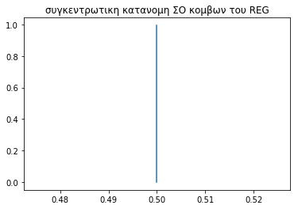

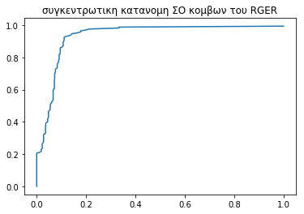

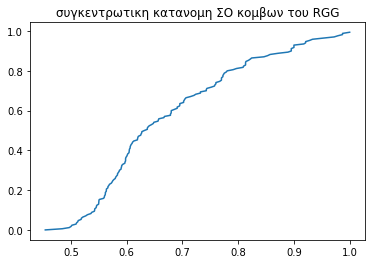

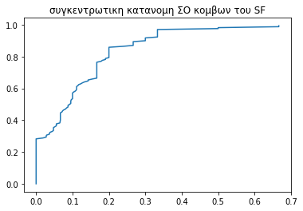

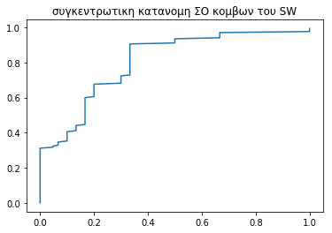

```python
# χρησιμοποιήστε την clustering του networkx για τον υπολογισμό του ΣΟ

def calculate_clust_coef(G):
    return nx.clustering(G)

REG_clust_coef = calculate_clust_coef(REG)
RGER_clust_coef = calculate_clust_coef(RGER)
RGG_clust_coef = calculate_clust_coef(RGG)
SF_clust_coef = calculate_clust_coef(SF)
SW_clust_coef = calculate_clust_coef(SW)

#συγκεντρωτική κατανομή του ΣΟ
Xreg = np.sort(list(REG_clust_coef.values()))
Xrger = np.sort(list(RGER_clust_coef.values()))
Xrgg = np.sort(list(RGG_clust_coef.values()))
Xsf = np.sort(list(SF_clust_coef.values()))
Xsw = np.sort(list(SW_clust_coef.values()))
Y = np.array(range(n))/float(n)
plt.figure(6)
plt.title("συγκεντρωτικη κατανομη ΣΟ κομβων του REG")
plt.plot(Xreg, Y)
plt.figure(7)
plt.title("συγκεντρωτικη κατανομη ΣΟ κομβων του RGER")
plt.plot(Xrger, Y)
plt.figure(8)
plt.title("συγκεντρωτικη κατανομη ΣΟ κομβων του RGG")
plt.plot(Xrgg, Y)
plt.figure(9)
plt.title("συγκεντρωτικη κατανομη ΣΟ κομβων του SF")
plt.plot(Xsf, Y)
plt.figure(10)
plt.title("συγκεντρωτικη κατανομη ΣΟ κομβων του SW")
plt.plot(Xsw, Y)
```

Στη συνέχεια να υπολογιστεί και να συγκριθεί ο μέσος ΣΟ κάθε τοπολογίας.

```python
print("Mean clustering coefficient REG: " + str(np.mean(list(REG_clust_coef.values()))))
print("Mean clustering coefficient RGER: " + str(np.mean(list(RGER_clust_coef.values()))))
print("Mean clustering coefficient RGG: " + str(np.mean(list(RGG_clust_coef.values()))))
print("Mean clustering coefficient SF: " + str(np.mean(list(SF_clust_coef.values()))))
print("Mean clustering coefficient SW: " + str(np.mean(list(SW_clust_coef.values()))))
```

```
Mean clustering coefficient REG: 0.5
Mean clustering coefficient RGER: 0.06351222019042088
Mean clustering coefficient RGG: 0.6732516282385607
Mean clustering coefficient SF: 0.1143967808615461
Mean clustering coefficient SW: 0.1911484593837535
```

Για το REG model, περιμένουμε σταθερό mean clustering coefficient, αφού κάθε κόμβος έχει σταθερό degree(4) και συνδέεται με κόμβους που έχουν το ίδιο degree με αυτόν (4) κοκ. Έτσι, το mean clustering coefficient θα είναι σταθερό, εδώ 0.5.

Για το RGER model, περιμένουμε αρκετά μικρό mean clustering coefficient, αφού το degree του κόμβου ακολουθεί την Poisson distribution, με αποτέλεσμα κάποιοι κόμβοι διάσπαρτα στην κατανομή να συνδέονται με πολλούς άλλους και οι υπόλοιποι να έχουν λίγες συνδέσεις. Αυτό σημαίνει ότι οι γείτονες του κάθε κόμβου μάλλον δεν θα συνδέονται μεταξύ τους. Άρα, μικρό το mean clustering coefficient.

Για το RGG model, περιμένουμε σχετικά μεγάλο mean clustering coefficient, αφού το r που έχουμε είναι σχετικά μεγάλο και άρα επιτρέπει πολλές συνδέσεις, άρα και συνδέσεις ανάμεσα σε γείτονες ενός κόμβου.

Τέλος για το SF και SW models, περιμένουμε μικρά mean clustering coefficients, αφού από την φύση τους απαιτούν οι γείτονες ενός κόμβου να μην συνδέονται κατά πλειοψηφία.